# La Política de la Corrupción

Sesión 4: La corrupción como equilibrio: normas y acción colectiva

Bogdan G. Popescu

bgpopescu@tec.mx

Tecnológico de Monterrey

## La petición

- Veinte dólares ahora, o una semana que no puede darse el lujo de perder.
- La tarifa está publicada en la pared. Los veinte dólares son por no esperar una semana.
- Aquí no hay nada oculto: ella sabe exactamente qué le están vendiendo.

Y no está sola en la fila. Detrás de ella hay un comerciante, una cocinera y un chofer, todos con los mismos trámites y el mismo funcionario.

**Tres respuestas, una por una. Atentos a quién no está de acuerdo.**

## Todos están de acuerdo

- Sofía, la cocinera y el chofer dicen exactamente lo mismo.
- Ninguno defiende el soborno.
- En una encuesta registraríamos tres respuestas impecables.

**La norma no falta, entonces. ¿Basta con tenerla?**

## Una hora después, en la ventanilla

La fila no se ha ido. El funcionario tampoco.

## Lo que Sofía está viendo

- Ella no se ha movido. Los demás sí.
- Nada de lo que cree sobre el soborno ha cambiado.
- Lo que cambió es lo que ahora espera que haga la fila.

**Si todos los demás pagan, ¿qué compra exactamente su negativa?**

## ¿Qué acaba de pasar?

- Cuatro personas que llaman incorrecto al soborno. Cuatro personas que pagan.
- A nadie lo convencieron de abandonar sus principios.
- Cada quien actuó según lo que esperaba de los demás.

Todos conservaron la regla en la cabeza. Nadie la cumplió en la ventanilla.

**¿Es hipocresía, o es una trampa?**

## El enigma — y la ruta de hoy

Cuatro personas que dijeron que el soborno está mal. Cuatro personas que pagaron. **Ninguna cambió de opinión.**

El enigma no es por qué la gente *aprueba* la corrupción. Casi nadie la aprueba. Es por qué la desaprobación tantas veces no alcanza para detenerla.

**Cuatro preguntas:**

1. ¿Qué hace que una regla obligue, y qué fue lo que faltó aquí?
2. Sofía es inventada. ¿Algo de esto pasa **de verdad**?
3. ¿Un funcionario deshonesto, o una trampa que atrapa a todos?
4. Si es una trampa, ¿qué puede hacer realmente una reforma?

# I. ¿Por qué participa la gente?

Qué es realmente una norma, por qué puede dejar de obligar, y si viaja con las personas.

## Dos preguntas que uno se hace sin darse cuenta

Casi todos coinciden en que el soborno está mal. Así que la **regla** no es lo que falta.

Entonces, ¿qué hace que una regla realmente obligue? Antes de seguir una, uno revisa en silencio dos cosas:

- **¿Alguien lo cumple de verdad?**
- **¿A alguien le molestaría si yo no lo cumpliera?**

**Expectativa empírica** — lo que creo que los demás *realmente hacen*.

**Expectativa normativa** — lo que creo que los demás *esperan de mí*.

Una regla obliga solo cuando **ambas** respuestas son sí. Bicchieri lo llama una **preferencia condicional**: quiero seguir la regla *siempre que* los demás también la sigan.

Bicchieri (2006), *The Grammar of Society*, cap. 1.

## Cuatro aduanas a las que Sofía pudo haber llegado

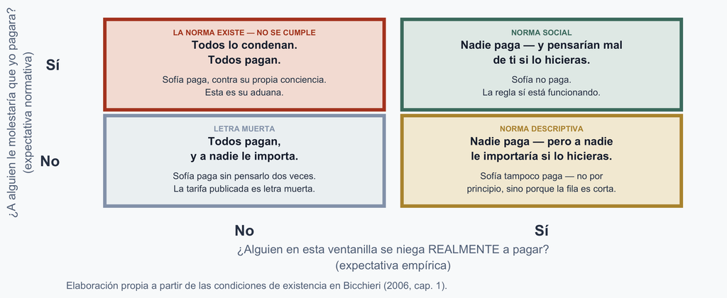

Sofía está en el cuadro superior izquierdo. Un sí de dos: la regla sigue en la cabeza de todos, solo que ya no describe a la fila. Ambas respuestas tienen que ser sí.

## Por qué bastaron tres personas

- Cada persona que paga hace que pagar tenga más sentido para la siguiente en la fila.
- Por eso los cambios pequeños rebotan: durante años, la norma no se mueve.
- Luego se acumulan los suficientes, se cruza el **punto de inflexión**, y la vieja norma cae de golpe.

**Punto de inflexión** — el momento en que ya cambiaron suficientes personas como para que cambiar sea también lo sensato para los demás.

Burke y Young (2011), “Social Norms”, *Handbook of Social Economics*, cap. 8.

## Plano, luego un precipicio, luego plano otra vez

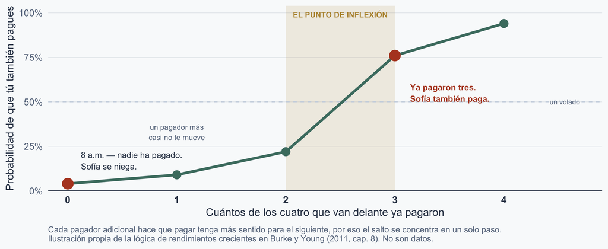

Sofía no necesitaba que pagaran todos. Necesitaba que pagaran **suficientes**.

## Entonces, ¿por qué no copiamos sin más a los locales?

- Uno esperaría que al mudarse a un lugar honesto se adopten hábitos honestos. Muchas veces no ocurre.
- Simpser estudia a personas **nacidas y criadas en un mismo país**, bajo las mismas leyes y la misma policía, cuyos **padres** vinieron de países distintos.
- Sus actitudes hacia el soborno siguen el patrón del país de los **padres**, una generación completa después.
- Mantenerse cerca de la familia y de la comunidad es lo que vuelve costoso adaptarse.

Una actitud puede sobrevivir al lugar que la produjo.

Simpser (2020), *The Culture of Corruption across Generations*. El argumento del costo de adaptarse es de Lazear (1999).

## Mismo país, padres distintos

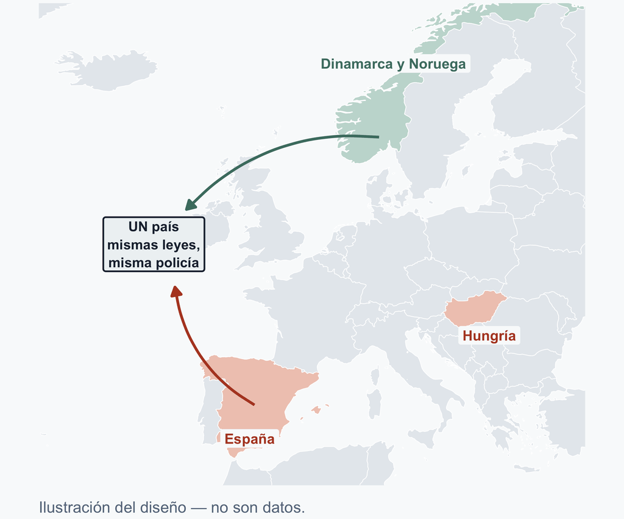

**La pregunta exacta** (Encuesta Social Europea, 2004):

*“¿Qué tan incorrecto le parece, si acaso, el siguiente comportamiento: que un funcionario público pida un favor o un soborno a cambio de sus servicios?”*

Respuestas: nada incorrecto · un poco incorrecto · incorrecto · **muy incorrecto**

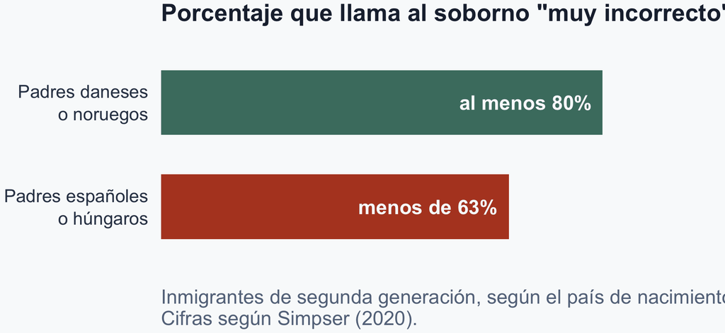

## Lo que esto resuelve y lo que no

- **No** convierte a la cultura en destino: Simpser también encuentra que las actitudes cambian entre generaciones.
- Cambian lentamente donde se tolera el soborno, y más rápido donde se castiga.
- Y no explica a Sofía: nada de su crianza cambió entre la mañana y la tarde.

**Dos fuerzas, entonces: lo que uno trae consigo, y lo que hoy hace la fila de enfrente.**

# II. ¿Se refleja en el comportamiento?

## ¿Cómo separar las reglas de las normas?

- Quienes vienen de países corruptos también enfrentan menos aplicación de la ley en casa
- Comparar países no nos dice cuál de las dos cosas importa
- Haría falta gente de muchos países bajo reglas **idénticas**
- Y un momento en que cambien las reglas pero no las personas

Fisman y Miguel (2007) encontraron un lugar donde ambas cosas se cumplían.

## La inmunidad diplomática como experimento natural

[figure not shown]

- Alrededor de 1,700 diplomáticos de la ONU, de 149 países
- Casi todas las misiones están a menos de una milla de la sede de la ONU
- Misma ciudad, mismas calles, mismos señalamientos de estacionamiento
- Antes de noviembre de 2002, una multa impaga no les costaba **nada**
- Así que su forma de estacionarse revelaba lo que traían consigo

Diseño de Fisman y Miguel (2007).

## Misma ciudad, mismas calles, mismos señalamientos

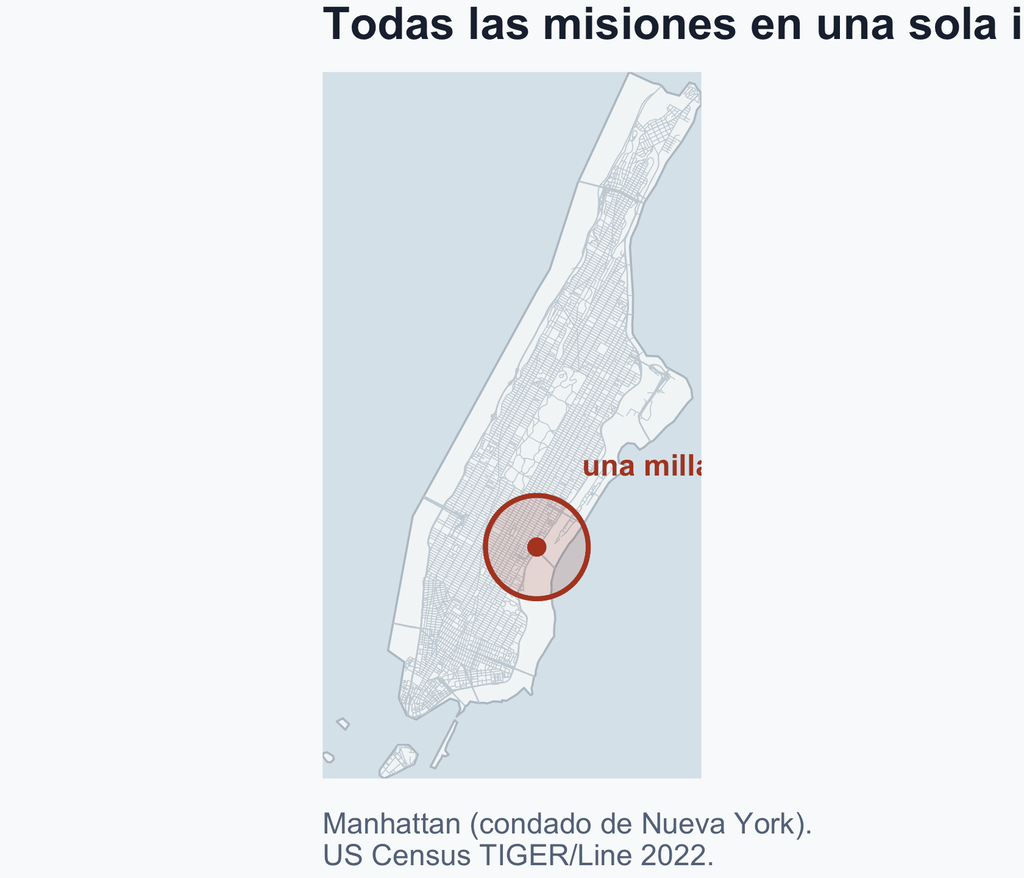

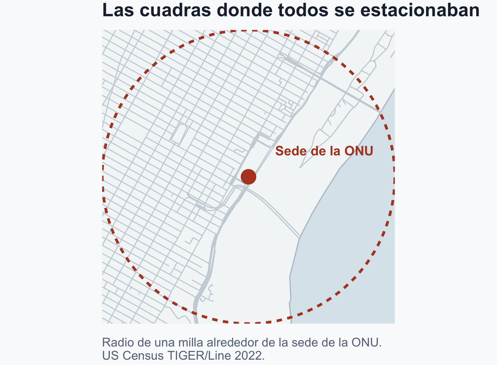

Mismas calles, mismos señalamientos, mismos inspectores. Lo que difería no eran las reglas.

## Tres cuadras junto al East River

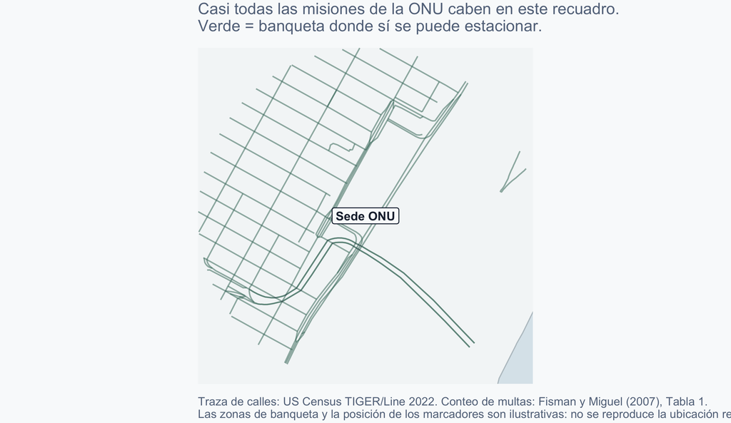

## Dónde no se puede estacionar

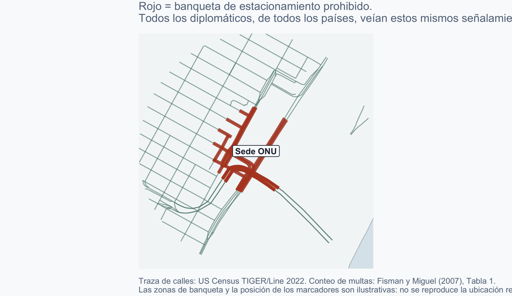

## Los diplomáticos de Alemania: una multa en todo el año

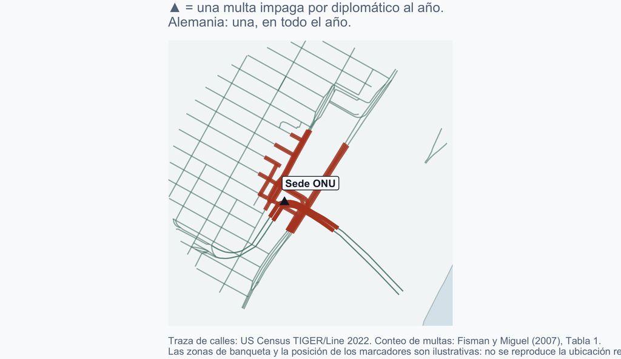

## Los diplomáticos de Egipto: 141 cada uno

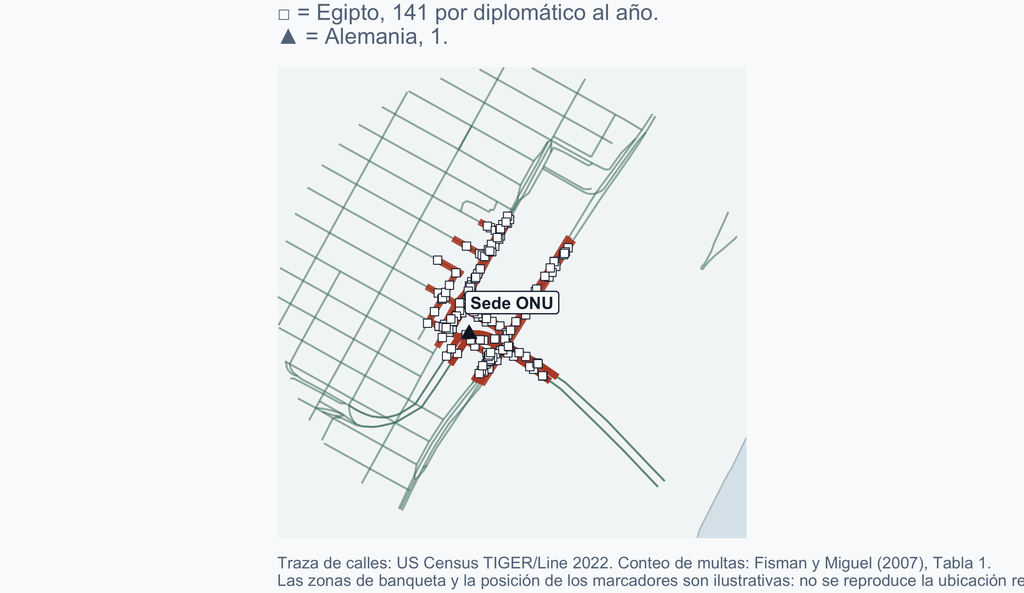

Los señalamientos, los inspectores y la sanción eran iguales para todos aquí. Lo único distinto eran los conductores.

## 150,000 multas. 18 millones de dólares. Nada cobrado.

Ninguna traía consigo una sanción. Lo que gobernaba cómo se estacionaban estos diplomáticos **no** era la ley.

Fisman y Miguel (2007). Alrededor de 1,700 diplomáticos de 149 países.

## Cuando nadie vigilaba

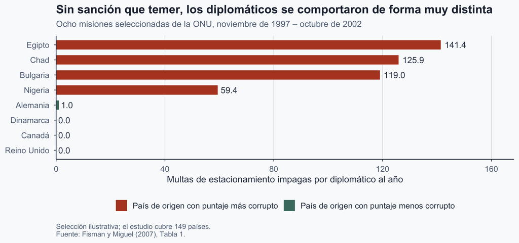

## Lo que la comparación sí y no puede mostrar

- El patrón es real, pero no es perfecto
- Kuwait, el peor infractor de todos, salía con puntaje relativamente limpio
- Las misiones pequeñas tienen pocos autos, así que se estacionan mal menos veces
- Por eso los autores compararon países **ajustando por el tamaño de la misión**

Con ese ajuste, pasar del puntaje de Nigeria al de Noruega implica una caída de alrededor del **80%** en las infracciones.

## Y entonces llegó la sanción

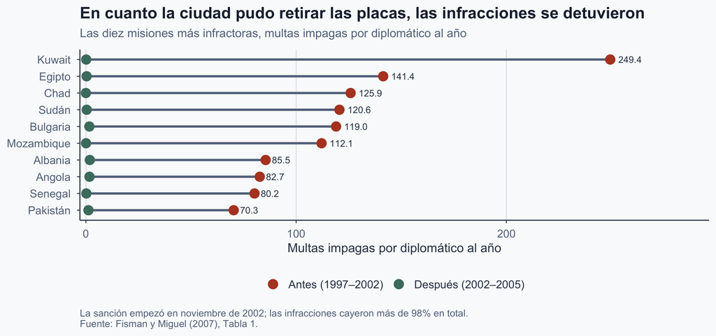

## Lo que nos enseñan los diplomáticos

- Durante cinco años **no hubo sanción alguna**. Lo único que quedaba era lo que cada diplomático traía consigo.
- Y eso variaba enormemente: **141 multas impagas al año, frente a 1**.
- Luego empezaron a retirar las placas. Las infracciones cayeron **98%** en cuestión de meses.

Importaron las dos cosas, en momentos distintos: lo que traían consigo mientras nada se aplicaba, y las placas cuando algo empezó a aplicarse.

**Sigue abierto:** algo viaja con las personas. Pero ¿*qué*? ¿Una creencia sobre los demás, un hábito, una convicción? Ese es el siguiente estudio.

## ¿Creer que se está extendiendo hace que la gente soborne?

- **La pregunta:** ¿enterarse de que la corrupción va en aumento hace que la gente participe?
- **La prueba:** 4,200 personas entrevistadas en la principal zona urbana de Costa Rica
- A algunas, elegidas al azar, se les mostró un volante que informaba que la corrupción aumentaba
- Después se les preguntó a todas si sobornarían a un agente de tránsito

Como el volante se asignó al azar, cualquier diferencia la causa la información.

Corbacho, Gingerich, Oliveros y Ruiz-Vega (2016).

## Lo que decía el volante

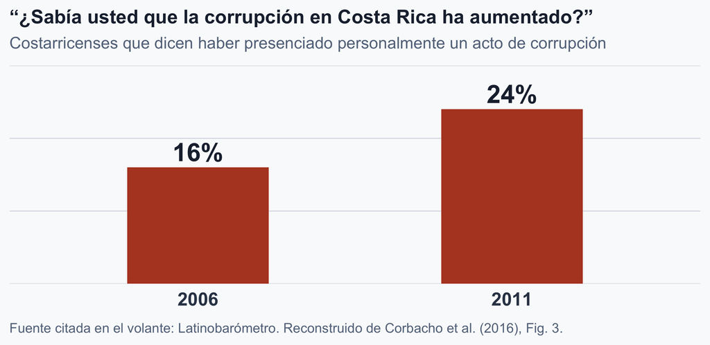

- Un tercio de la gente vio esto. Un tercio no vio nada.
- El último tercio vio un **placebo**: mismo diseño, malas noticias igual de malas, pero sobre la lentitud de los tribunales.
- El placebo no cambió nada. Así que fue el *mensaje*, no el mal humor, lo que movió a la gente.

## Creer que la corrupción aumenta vuelve a la gente más dispuesta a sobornar

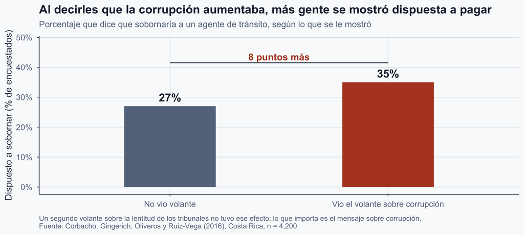

## Qué suman los dos estudios

- Los diplomáticos actuaron según normas traídas de casa, donde nada se aplicaba
- Los costarricenses se volvieron más **dispuestos** a sobornar al enterarse de que la corrupción aumentaba
- Los dos estudios hacen trabajos distintos: uno sigue el comportamiento, el otro aísla la creencia
- Y las expectativas pueden cumplirse a sí mismas

**Ojo con el hueco:** Corbacho mide la *disposición declarada*, no el soborno observado. Fisman y Miguel miden comportamiento real, pero no nos dicen *cuál* disposición aprendida está actuando.

**Sigue:** si el problema son las expectativas, ¿a qué debería apuntar realmente una reforma?

# III. Problema principal–agente frente a problema de acción colectiva

## El contenedor pasa. Ahora necesita un permiso.

- Sofía pagó los 20 dólares. La pluma se levantó; la carga pasó.
- Para sacarla del patio necesita un permiso de la Oficina de Permisos de Northland.
- Otro edificio, otra fila, la misma pregunta esperándola.

**Dos versiones de esa oficina. Observen qué cambia.**

## Historia A — una ventanilla pide

- Cuatro ventanillas. Tres atienden a sus vecinos de fila sin decir nada.
- En la ventanilla 2, el empleado menciona una cifra: **veinte dólares**, el mismo precio que en la aduana.
- Detrás del cristal, al fondo, hay un supervisor que quiere que los permisos se expidan como debe ser.
- Sencillamente no alcanza a ver lo que pasa en el mostrador.

**Pregúntense:** ¿cuál es exactamente el problema aquí, y quién podría resolverlo?

## Historia B — todas las ventanillas piden

- Misma oficina, misma fila, misma Sofía. Esta vez **todos** los empleados mencionan una cifra.
- El supervisor dejó su escritorio. Está en el mostrador, tomando su parte.
- Denunciarlo significaría denunciar ante el hombre que se queda con la tajada.
- Negarse no le consigue un permiso limpio. No le consigue ningún permiso.

## Dos nombres para dos problemas

El mismo pago corrupto, dos situaciones muy distintas. Síntesis propia de Persson, Rothstein y Teorell (2013).

|  | **Historia A** | **Historia B** |
| --- | --- | --- |
| Qué falla | Una persona esconde su mala conducta | Todos esperan que todos los demás hagan trampa |
| Quién puede arreglarlo | El jefe, vigilando más de cerca | Nadie actuando por su cuenta |
| Los honestos son | Lo normal | Castigados por ingenuos |
| Los politólogos lo llaman | Un problema **principal–agente** | Un problema de **acción colectiva** |

## El problema principal–agente

Alguien encarga un trabajo a otra persona, y no puede vigilar cómo lo hace.

- **El principal** — el supervisor. Quiere que los permisos se expidan bien.
- **El agente** — el empleado. Quiere los veinte dólares.
- Quieren **cosas distintas**, y solo uno de los dos está en el mostrador.
- El empleado sabe lo que pasó ahí. El supervisor no.

Ese hueco tiene nombre: **asimetría de información**. Es lo que hace posible la traición.

**Y la solución parece obvia**: vigilar más de cerca, auditar, subir la sanción. Funciona porque *alguien arriba quiere que se resuelva*.

Rose-Ackerman (1978); Klitgaard (1988), quien resume el diagnóstico como *monopolio más discrecionalidad menos rendición de cuentas*. El encuadre sigue a Persson, Rothstein y Teorell (2013).

## El problema de acción colectiva

Todos estarían mejor si nadie pagara. Cada quien por separado sigue estando mejor si paga.

- **Nadie queda fuera**: empleados, solicitantes y supervisor persiguen su propio interés.
- Lo que es sensato **para mí** depende de lo que espero **de ti**.
- Entre más gente se espere que pague, más sentido tiene pagar.
- Pasado cierto punto se invierte: si pagan suficientes, sumarse es sencillamente lo que hace una persona sensata.

**Y ahora no hay principal.** La teoría principal–agente supone que alguien quiere que se apliquen las reglas. La teoría de acción colectiva pregunta si alguien realmente lo quiere, incluido el supervisor, que se está llevando una parte.

Persson, Rothstein y Teorell (2013), a partir de Ostrom (1998).

## Equilibrio

Una situación de la que nadie se saldrá por su cuenta, aunque todos preferirían que fuera distinta.

- Sofía preferiría una oficina donde nadie pagara.
- También el solicitante de junto. Y muy probablemente también los empleados.
- Pero dado lo que hacen todos los demás, pagar sigue siendo su mejor jugada.
- Negarse le cuesta el permiso, y nadie más se entera.

Sumen la mejor jugada de cada quien y obtienen una situación que nadie eligió y de la que nadie puede salir solo.

**Por eso “simplemente dejen de pagar” no es un consejo.** Le pide a una sola persona cargar con todo el costo de un cambio que necesita a todos.

La lectura de la corrupción como acción colectiva: Persson, Rothstein y Teorell (2013).

# IV. ¿Qué significa eso para la reforma?

Si la corrupción es un equilibrio y no una mala conducta oculta, ¿qué se sigue para la política pública?

## Por qué pueden fallar las reformas estándar

> Uno denuncia ante alguien que ya fue sobornado. Y ahí se acaba todo.
- **El diagnóstico habitual:** los agentes corruptos evaden la vigilancia.
- **El remedio habitual:** más vigilancia, agencias más fuertes, sanciones más altas.
- Pero las auditorías necesitan auditores honestos; las denuncias, a alguien dispuesto a actuar; el castigo, fiscales dispuestos a acusar.
- **El problema:** si el supervisor también se lleva una parte, ¿quién hace cumplir la reforma?

Entrevistas con más de 60 funcionarios, periodistas y personal de ONG de Kenia y Uganda (Persson, Rothstein y Teorell 2013).

## Kenia y Uganda hicieron todo lo que dice el manual

- **Kenia**: Ley Anticorrupción y de Delitos Económicos, Ley de Ética de los Servidores Públicos, y la Convención de la ONU contra la Corrupción.
- **Uganda**: la Inspección General del Gobierno como agencia anticorrupción, más Auditoría General y Dirección de Ética e Integridad.
- Global Integrity calificó ambos marcos legales de “muy sólidos”: **100 sobre 100**.

Después midió cuánto de todo eso llegaba a aplicarse.

La brecha entre la ley y la práctica: **“grande” en Kenia, “enorme” en Uganda.** Desde 1998, la corrupción en ambos países no ha dejado de ser generalizada.

Vigilar más de cerca no está mal. Solo que da por supuesto justo lo que falta: alguien que quiera vigilar.

Global Integrity (2008), reportado en Persson, Rothstein y Teorell (2013).

## ¿Qué tendría que cambiar?

- **El comportamiento**: la gente tiene que encontrarse de verdad con reglas y consecuencias distintas.
- **Las expectativas**: la gente tiene que tener motivos para pensar que los demás también se encontraron con ellas.
- Supongan que la policía de verdad se limpió.
- Ustedes lo creen.
- Pero piensan que los demás siguen esperando pagar.
- Así que pagan de todos modos, y lo mismo hace cada quien que razona igual.

Tengo que creer que las reglas cambiaron, y además pensar que tú también lo crees. Lo segundo es lo difícil.

## ¿Qué podría volver creíble una reforma?

- **Visible**: la gente puede ver que la conducta cambió de verdad, no solo que se aprobó una ley.
- **Creíble**: la sanción de verdad ocurre, incluso contra los de adentro.
- **Coordinada**: denuncia, procuración de justicia y personal se mueven juntos, en vez de cambiar una regla en el papel.

Un ministro procesado funciona sobre todo como **información**: le avisa a todos que todos los demás acaban de ver lo mismo.

**Cuidado.** La teoría de acción colectiva *predice* que estas tres cosas deberían importar. Los estudios de esta sesión no establecen cuál es el mejor paquete de reformas.

## ¿Qué sabemos realmente?

Dónde terminan los hallazgos y empieza la receta.

| Lo que la evidencia sostiene | Lo que la teoría infiere de ello |
| --- | --- |
| Las normas viajan con las personas, incluso donde nada se aplica | La corrupción puede asentarse en un equilibrio que se sostiene solo |
| Decirle a la gente que la corrupción aumenta eleva su **disposición** a sobornar | La reforma debe cambiar lo que la gente espera de los demás |
| Una sanción creíble cambió la conducta de los diplomáticos en meses | La sanción funciona a través de la creencia, no solo del castigo |
| *(aquí no hay evidencia directa)* | La reforma coordinada supera a los arreglos aislados |

Ese último renglón es lo que en la Sesión 2 llamaríamos **plausible pero no establecido**, y es justo el renglón sobre el que descansa todo el argumento de reforma. Presiónenlo.

## Ejercicio — Ustedes dirigen la Oficina de Permisos

Todos los empleados de la Oficina de Permisos cobran veinte dólares. Su antecesor se llevaba una parte. Tres meses, sin presupuesto. **Elijan dos:**

1. Despedir a los dos peores empleados
2. Poner una cámara en cada ventanilla
3. Subir la sanción por recibir un pago
4. Publicar cada semana cuántos permisos se dieron sin pago
5. Procesar públicamente a su antecesor

**Para cada una:**

- **¿Qué pasa a la mañana siguiente?** ¿Alguien deja de pedir los veinte dólares, y por qué?
- **¿Qué la haría fracasar?** ¿Quién puede ignorarla, sabotearla o simularla?

## Para llevarse

- **Todos ya sabemos que el soborno está mal.** Eso nunca fue lo que faltaba. Lo que falló en la ventanilla de Sofía fue esperar que alguien más se negara.
- **Importan la persona y el entorno.** Los diplomáticos conservaron sus hábitos de origen cuando nada se aplicaba; a los costarricenses les dijeron que la corrupción aumentaba y se volvieron más dispuestos a pagar.
- **Un empleado corrupto y una oficina capturada se ven igual desde fuera.** El primero necesita un jefe atento. La segunda ya no tiene quién vigile.
- **Por eso el diagnóstico va antes que la receta.** Las cámaras y las sanciones arreglan la primera oficina y rebotan en la segunda.
- **Y sabemos mejor que la trampa existe que cómo salir de ella.**

La corrupción sobrevive no porque todos la quieran, sino porque cada quien puede estar esperando a que los demás dejen de hacerlo primero.

## Referencias

Corbacho, A., Gingerich, D. W., Oliveros, V., & Ruiz-Vega, M. (2016). Corruption as a self-fulfilling prophecy: Evidence from a survey experiment in Costa Rica. *American Journal of Political Science, 60*(4), 1077–1092. https://doi.org/10.1111/ajps.12244

Fisman, R., & Miguel, E. (2007). Corruption, norms, and legal enforcement: Evidence from diplomatic parking tickets. *Journal of Political Economy, 115*(6), 1020–1048. https://doi.org/10.1086/527495

Global Integrity. (2008). *Global Integrity report 2008*. Global Integrity.

Kaufmann, D., Kraay, A., & Mastruzzi, M. (2005). *Governance matters IV: Governance indicators for 1996–2004* (Policy Research Working Paper No. 3630). World Bank.

Klitgaard, R. (1988). *Controlling corruption*. University of California Press.

## Referencias (continuación)

Persson, A., Rothstein, B., & Teorell, J. (2013). Why anticorruption reforms fail—Systemic corruption as a collective action problem. *Governance, 26*(3), 449–471. https://doi.org/10.1111/j.1468-0491.2012.01604.x

Rose-Ackerman, S. (1978). *Corruption: A study in political economy*. Academic Press.

Rothstein, B. (2011). *The quality of government: Corruption, social trust, and inequality in international perspective*. University of Chicago Press.